# Bayesian Modeling Problem Set 3

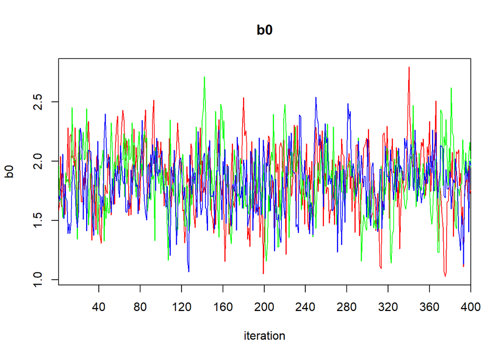

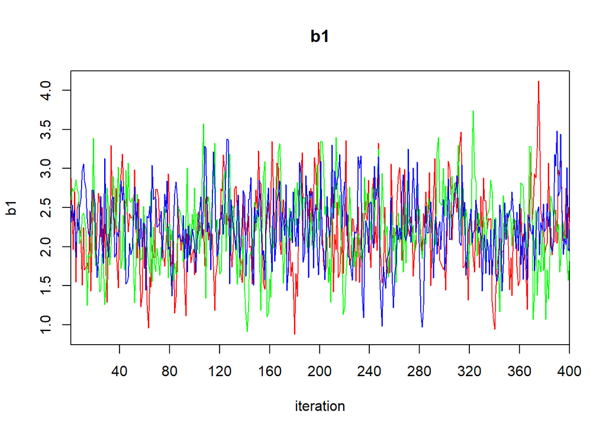

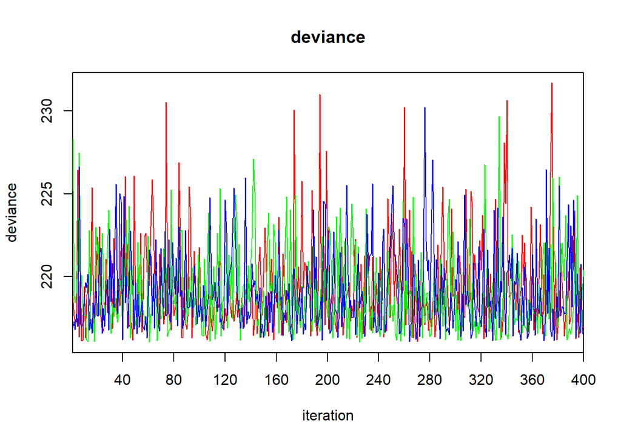

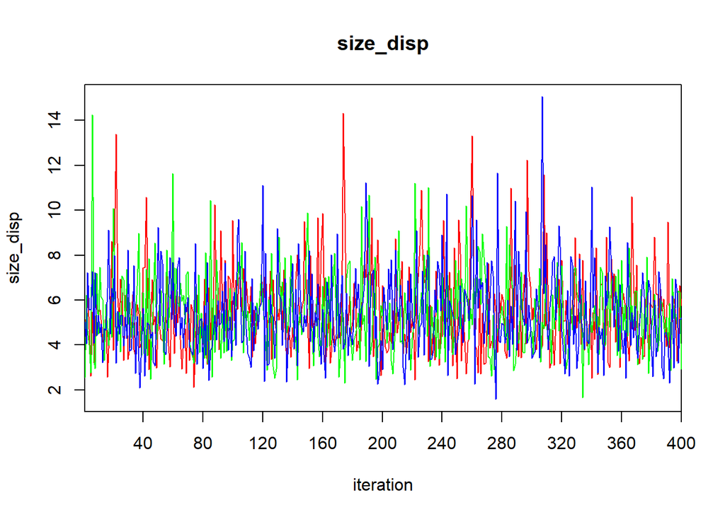

```r
traceplot(penguin.fit2)
```

```r
#the plot looks like a hairy caterpillar, hence it is very likely the model has converged
```

12. If you have written your model correction in 11 and used vague priors, then your estimated parameters should match to the frequentist results you calculated in step 3. Check that now.[^4]

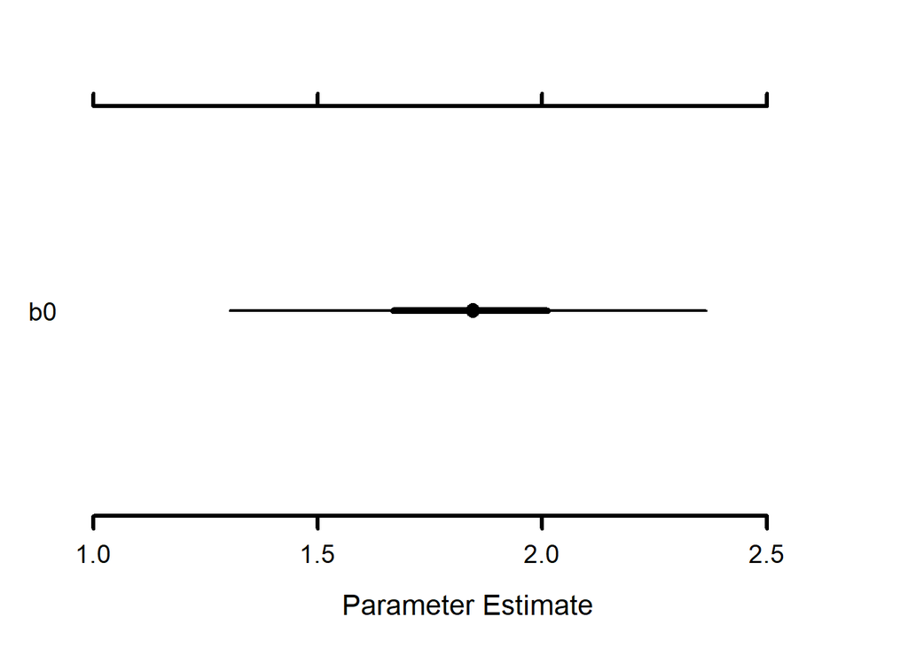

```r
MCMCvis::MCMCplot(penguin.fit2,params="b0")
```

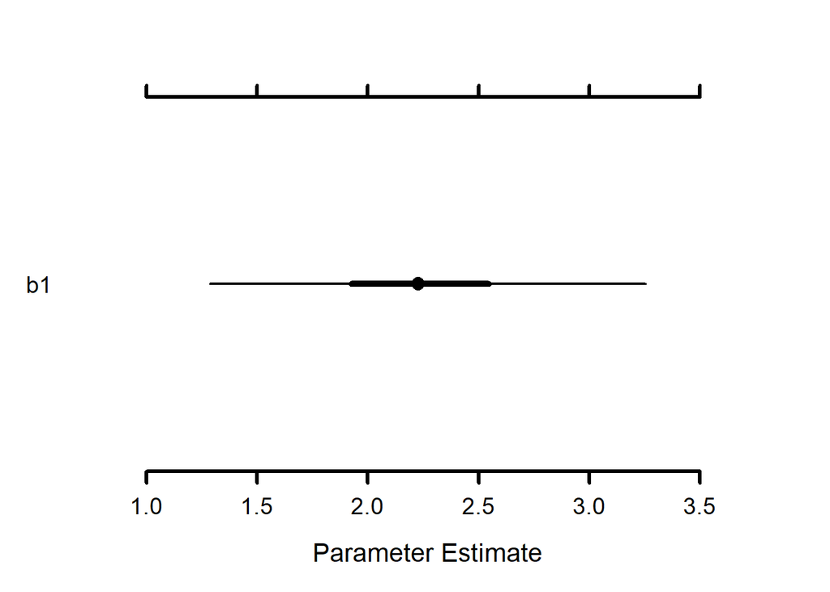

```r
MCMCvis::MCMCplot(penguin.fit2,params="b1")
```

```r
MCMCvis::MCMCsummary(penguin.fit2)
```

```
##                 mean        sd       2.5%        50%      97.5% Rhat n.eff
## b0          1.838094 0.2694752   1.304762   1.846171   2.364785 1.00   453
## b1          2.240974 0.4776415   1.288176   2.227024   3.254064 1.00   499
## deviance  219.221968 2.5688990 216.206289 218.582321 225.515273 1.00  1036
## size_disp   5.441198 1.8510757   2.625370   5.216222   9.867933 1.01  1265
```

```r
#According to the plot, and the summary the estimated parameter values do match closely with the calculated value in step 3
```

[output not shown]

13. Finally, with your Bayesian negative binomial model of penguin counts, create a plot (per question 10) but now predict the posterior lines from the negative binomial model. In plotting your posterior lines, remember to consider the effect of link functions, which means that we can’t use simple `abline()’; rather, we will need to create a dense sequence (e.g., n=1000) of x-values for plotting, use the posterior distribution of the linear predictors to estimate the expected values along the full sequence for every posterior draw, and then plot those coordinates.

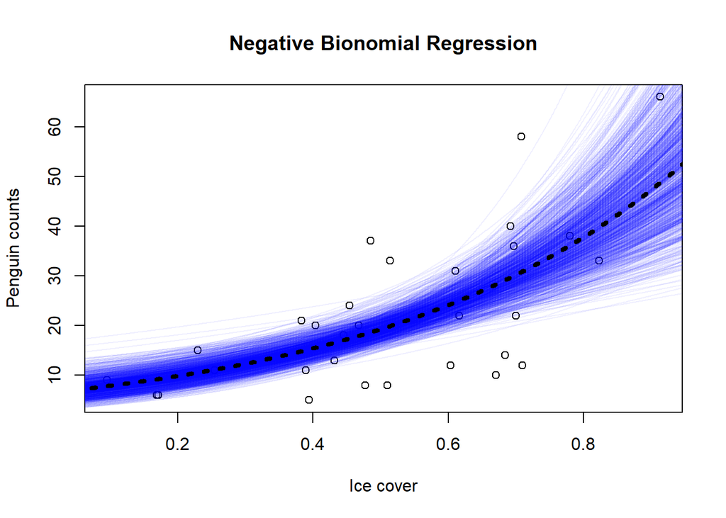

```r
plot(ice, penguin, xlab = "Ice cover", ylab = "Penguin counts",main="Negative Bionomial Regression")
x=seq(0,1,0.001)
for(i in 1:length(MCMCchains(penguin.fit2, "b0"))) {
  lines(x,exp(MCMCchains(penguin.fit2, "b0")[i]+MCMCchains(penguin.fit2, "b1")[i]*x),col = "#0000FF10")
}
lines(x, exp(MCMCpstr(penguin.fit2)$b0+MCMCpstr(penguin.fit2)$b1*x), col = "black", lwd = 4, lty = 3)
```

[^1]: use the function `MCMCchains()`
[^2]: again, look at lecture 03-1 code for assistance
[^3]: a good opportunity to look through the JAGS User Manual provided on BruinLearn
[^4]: if not, keep working on your model code!